# CITS4009 - Project 1

Neha SHARMA (23747726)

PROJECT GOALS

The main aim of this project is to develop understanding of the data and explain the findings through visualizations. EDA plays an important part in data visualization because it helps in generation of the hypothesis.

INRODUCTION

This is the US Mining Accident data set which covers all mines in US.This data is analyzed and is obtained from Data.gov website, which is published by Us Department of Labour.The entire dataset is collected from year 2000 to 2015. This data contains the accidents that occur during mining in the span of 15 years. This data has 57 attributes and 2000 records.

SETTING UP LIBRARIES

Libraries Used for the project

1. tidyverse
2. ggplot2
3. scales
4. patchwork
5. gapminder
6. plotly
7. ggcorrplot

Importing Libraries

```r
library(tidyverse)
library(ggplot2)
library(scales)
library(patchwork)
library(gapminder)
library(plotly)
library(ggcorrplot)
theme_set(theme_classic())
```

DATA OVERVIEW

Reading The Data

```r
accidents <- read.csv(file = 'C:/Users/neha0/Desktop/UWA SEM 1/Computataional Data Analysis/us_data_2000.csv')
```

Viewing The Data

glimpse() makes it possible to see every column data in a dataframe.

```r
glimpse(accidents)
```

```
Rows: 2,000
Columns: 57
$ MINE_ID             <int> 100003, 100003, 100008, 100011, 100011, 100011, 100011, 100011, 100016, 100021, 1…
$ CONTROLLER_ID       <chr> "41044", "41044", "M31753", "M11763", "M11763", "M11763", "M11763", "M11763", "M0…
$ CONTROLLER_NAME     <chr> "Lhoist Group", "Lhoist Group", "Alan B  Cheney", "Imerys S A", "Imerys S A", "Im…
$ OPERATOR_ID         <chr> "L13586", "L13586", "L31753", "L17074", "L17074", "L17074", "90005", "90005", "L1…
$ OPERATOR_NAME       <chr> "Lhoist North America ", "Lhoist North America ", "Cheney Lime & Cement Company",…
$ CONTRACTOR_ID       <chr> "", "", "", "", "", "", "", "", "", "", "", "", "", "", "", "", "", "", "C037", "…
$ DOCUMENT_NO         <dbl> 2.2e+11, 2.2e+11, 2.2e+11, 2.2e+11, 2.2e+11, 2.2e+11, 2.2e+11, 2.2e+11, 2.2e+11, …
$ SUBUNIT_CD          <int> 3, 30, 30, 30, 30, 30, 30, 30, 3, 3, 30, 30, 30, 30, 30, 3, 30, 30, 30, 30, 30, 3…
$ SUBUNIT             <chr> "STRIP, QUARY, OPEN PIT", "MILL OPERATION/PREPARATION PLANT", "MILL OPERATION/PRE…
$ ACCIDENT_DT         <chr> "14/03/2012", "8/01/2007", "4/07/2009", "26/05/2000", "22/01/2005", "29/03/2006",…
$ CAL_YR              <int> 2012, 2007, 2009, 2000, 2005, 2006, 2008, 2012, 2000, 2006, 2007, 2000, 2002, 201…
$ CAL_QTR             <int> 1, 1, 3, 2, 1, 1, 4, 2, 3, 1, 1, 4, 3, 3, 2, 1, 3, 4, 1, 3, 1, 3, 3, 3, 1, 2, 3, …
$ FISCAL_YR           <int> 2012, 2007, 2009, 2000, 2005, 2006, 2009, 2012, 2000, 2006, 2007, 2001, 2002, 201…
```

[output cut: 44 more lines]

summary() function computes summary statistics of data and model objects.

```r
  summary(accidents)
```

```
    MINE_ID        CONTROLLER_ID      CONTROLLER_NAME    OPERATOR_ID        OPERATOR_NAME
 Min.   : 100003   Length:2000        Length:2000        Length:2000        Length:2000
 1st Qu.: 900482   Class :character   Class :character   Class :character   Class :character
 Median :1516874   Mode  :character   Mode  :character   Mode  :character   Mode  :character
 Mean   :1622517
 3rd Qu.:2401879
 Max.   :3603460

 CONTRACTOR_ID       DOCUMENT_NO        SUBUNIT_CD       SUBUNIT          ACCIDENT_DT            CAL_YR
 Length:2000        Min.   :2.2e+11   Min.   : 1.000   Length:2000        Length:2000        Min.   :2000
 Class :character   1st Qu.:2.2e+11   1st Qu.: 1.000   Class :character   Class :character   1st Qu.:2002
 Mode  :character   Median :2.2e+11   Median : 3.000   Mode  :character   Mode  :character   Median :2006
                    Mean   :2.2e+11   Mean   : 9.996                                         Mean   :2006
                    3rd Qu.:2.2e+11   3rd Qu.:30.000                                         3rd Qu.:2009
                    Max.   :2.2e+11   Max.   :99.000                                         Max.   :2015

    CAL_QTR        FISCAL_YR      FISCAL_QTR    ACCIDENT_TIME  DEGREE_INJURY_CD   DEGREE_INJURY
 Min.   :1.000   Min.   :2000   Min.   :1.000   Min.   :  10   Length:2000        Length:2000
 1st Qu.:1.000   1st Qu.:2002   1st Qu.:2.000   1st Qu.: 845   Class :character   Class :character
 Median :2.000   Median :2006   Median :3.000   Median :1208   Mode  :character   Mode  :character
 Mean   :2.458   Mean   :2006   Mean   :2.574   Mean   :1801
 3rd Qu.:3.000   3rd Qu.:2010   3rd Qu.:4.000   3rd Qu.:1646
 Max.   :4.000   Max.   :2015   Max.   :4.000   Max.   :9999

 FIPS_STATE_CD   UG_LOCATION_CD     UG_LOCATION        UG_MINING_METHOD_CD UG_MINING_METHOD
 Min.   : 1.00   Length:2000        Length:2000        Length:2000         Length:2000
 1st Qu.:13.00   Class :character   Class :character   Class :character    Class :character
 Median :21.00   Mode  :character   Mode  :character   Mode  :character    Mode  :character
 Mean   :21.19
 3rd Qu.:30.00
 Max.   :42.00

 MINING_EQUIP_CD    MINING_EQUIP       EQUIP_MFR_CD       EQUIP_MFR_NAME     EQUIP_MODEL_NO
 Length:2000        Length:2000        Length:2000        Length:2000        Length:2000
 Class :character   Class :character   Class :character   Class :character   Class :character
 Mode  :character   Mode  :character   Mode  :character   Mode  :character   Mode  :character




```

[output cut: 33 more lines]

```
 Length:2000        Length:2000        Length:2000        Length:2000        Length:2000
 Class :character   Class :character   Class :character   Class :character   Class :character
 Mode  :character   Mode  :character   Mode  :character   Mode  :character   Mode  :character




 CLOSED_DOC_NO     COAL_METAL_IND
 Min.   :3.2e+11   Length:2000
 1st Qu.:3.2e+11   Class :character
 Median :3.2e+11   Mode  :character
 Mean   :3.2e+11
 3rd Qu.:3.2e+11
 Max.   :3.2e+11
 NA's   :1138
```

head(n) function is used to read first n rows of data set (n = number of rows).

```r
  accidents %>% head(5)
```

|  | MINE_ID | CONTROLLER_ID | CONTROLLER_NAME | OPERATOR_ID | OPERATOR_NAME | CONTRACTOR_ID | DOCUMENT_NO | SUBUNIT_CD | SUBUNIT | ACCIDENT_DT | CAL_YR | CAL_QTR | FISCAL_YR | FISCAL_QTR | ACCIDENT_TIME | DEGREE_INJURY_CD | DEGREE_INJURY | FIPS_STATE_CD | UG_LOCATION_CD | UG_LOCATION | UG_MINING_METHOD_CD | UG_MINING_METHOD | MINING_EQUIP_CD | MINING_EQUIP | EQUIP_MFR_CD | EQUIP_MFR_NAME | EQUIP_MODEL_NO | SHIFT_BEGIN_TIME | CLASSIFICATION_CD | … |
| --- | --- | --- | --- | --- | --- | --- | --- | --- | --- | --- | --- | --- | --- | --- | --- | --- | --- | --- | --- | --- | --- | --- | --- | --- | --- | --- | --- | --- | --- | --- |
| 1 | 100003 | 41044 | Lhoist Group | L13586 | Lhoist North America |  | 2.2e+11 | 3 | STRIP, QUARY, OPEN PIT | 14/03/2012 | 2012 | 1 | 2012 | 2 | 945 | 5 | DAYS RESTRICTED ACTIVITY ONLY | 1 | ? | NO VALUE FOUND | ? | NO VALUE FOUND | 24 | Front-end loader, Tractor-shovel, Payloader, Highlift, Skip loader | 119 | Not on this list | 22321 | 600 | 12 | … |
| 2 | 100003 | 41044 | Lhoist Group | L13586 | Lhoist North America |  | 2.2e+11 | 30 | MILL OPERATION/PREPARATION PLANT | 8/01/2007 | 2007 | 1 | 2007 | 2 | 1105 | 6 | NO DYS AWY FRM WRK,NO RSTR ACT | 1 | ? | NO VALUE FOUND | ? | NO VALUE FOUND | 28 | Hand tools (not powered) | 121 | Not Reported |  | 700 | 10 | … |
| 3 | 100008 | M31753 | Alan B Cheney | L31753 | Cheney Lime & Cement Company |  | 2.2e+11 | 30 | MILL OPERATION/PREPARATION PLANT | 4/07/2009 | 2009 | 3 | 2009 | 4 | 1000 | 3 | DAYS AWAY FROM WORK ONLY | 1 | ? | NO VALUE FOUND | ? | NO VALUE FOUND | ? | NO VALUE FOUND | ? | NO VALUE FOUND |  | 600 | 18 | … |
| 4 | 100011 | M11763 | Imerys S A | L17074 | Imerys Pigments LLC |  | 2.2e+11 | 30 | MILL OPERATION/PREPARATION PLANT | 26/05/2000 | 2000 | 2 | 2000 | 3 | 1100 | 5 | DAYS RESTRICTED ACTIVITY ONLY | 1 | ? | NO VALUE FOUND | ? | NO VALUE FOUND | ? | NO VALUE FOUND | ? | NO VALUE FOUND | ? | 700 | 9 | … |
| 5 | 100011 | M11763 | Imerys S A | L17074 | Imerys Pigments LLC |  | 2.2e+11 | 30 | MILL OPERATION/PREPARATION PLANT | 22/01/2005 | 2005 | 1 | 2005 | 2 | 1430 | 5 | DAYS RESTRICTED ACTIVITY ONLY | 1 | ? | NO VALUE FOUND | ? | NO VALUE FOUND | ? | NO VALUE FOUND | ? | NO VALUE FOUND |  | 700 | 9 | … |

tail(n) function is used to read last n rows of data set (n = number of rows).

```r
 accidents %>% tail(5)
```

|  | MINE_ID | CONTROLLER_ID | CONTROLLER_NAME | OPERATOR_ID | OPERATOR_NAME | CONTRACTOR_ID | DOCUMENT_NO | SUBUNIT_CD | SUBUNIT | ACCIDENT_DT | CAL_YR | CAL_QTR | FISCAL_YR | FISCAL_QTR | ACCIDENT_TIME | DEGREE_INJURY_CD | DEGREE_INJURY | FIPS_STATE_CD | UG_LOCATION_CD | UG_LOCATION | UG_MINING_METHOD_CD | UG_MINING_METHOD | MINING_EQUIP_CD | MINING_EQUIP | EQUIP_MFR_CD | EQUIP_MFR_NAME | EQUIP_MODEL_NO | SHIFT_BEGIN_TIME | CLASSIFICATION_CD | … |
| --- | --- | --- | --- | --- | --- | --- | --- | --- | --- | --- | --- | --- | --- | --- | --- | --- | --- | --- | --- | --- | --- | --- | --- | --- | --- | --- | --- | --- | --- | --- |
| 1996 | 3603248 | C15843 | Severstal Resources | P24228 | Rox Coal Inc. |  | 2.2e+11 | 1 | UNDERGROUND | 28/02/2000 | 2000 | 1 | 2000 | 2 | 850 | 3 | DAYS AWAY FROM WORK ONLY | 42 | 98 | OTHER | 5 | Continuous Mining | 12 | Continuous miner, Tunnel borer, Road header | 0 | Not Reported | ? | 600 | 17 | … |
| 1997 | 3603442 | M00271 | New Enterprise Stone & Lime Company Inc | L02478 | Martin Limestone Inc |  | 2.2e+11 | 30 | MILL OPERATION/PREPARATION PLANT | 30/03/2006 | 2006 | 1 | 2006 | 2 | 1500 | 4 | DYS AWY FRM WRK & RESTRCTD ACT | 42 | ? | NO VALUE FOUND | ? | NO VALUE FOUND | 40 | Milling machinery, Block press, Ballast machine | 119 | Not on this list |  | 630 | 17 | … |
| 1998 | 3603448 | M36169 | Star Group Inc | L36169 | Mercer Lime Company |  | 2.2e+11 | 30 | MILL OPERATION/PREPARATION PLANT | 27/03/2010 | 2010 | 1 | 2010 | 2 | 2030 | 3 | DAYS AWAY FROM WORK ONLY | 42 | ? | NO VALUE FOUND | ? | NO VALUE FOUND | ? | NO VALUE FOUND | ? | NO VALUE FOUND |  | 1400 | 9 | … |
| 1999 | 3603448 | M36169 | Star Group Inc | L36169 | Mercer Lime Company |  | 2.2e+11 | 30 | MILL OPERATION/PREPARATION PLANT | 16/03/2011 | 2011 | 1 | 2011 | 2 | 730 | 6 | NO DYS AWY FRM WRK,NO RSTR ACT | 42 | ? | NO VALUE FOUND | ? | NO VALUE FOUND | ? | NO VALUE FOUND | ? | NO VALUE FOUND |  | 530 | 18 | … |
| 2000 | 3603460 | M00639 | Specialty Granules Inc | L12236 | Specialty Granules Inc. | YPE | 2.2e+11 | 30 | MILL OPERATION/PREPARATION PLANT | 15/11/2006 | 2006 | 4 | 2007 | 1 | 600 | 6 | NO DYS AWY FRM WRK,NO RSTR ACT | 42 | ? | NO VALUE FOUND | ? | NO VALUE FOUND | ? | NO VALUE FOUND | ? | NO VALUE FOUND |  | 600 | 21 | … |

DATA CLEANING AND TRANSFORMATION

Data Cleaning is a crucial step to clean and validate the dataset before starting with analysis, visualization, or predictive modeling.

There are various techniques that are used for cleaning the data:

1. Remove duplicate values or irrelevant columns.
2. Filter unwanted outliers.
3. Handle missing data.
4. Remove empty data.

Converting Spaces and Question Mark Characters to NA

We have converted all the values containing empty spaces and question marks to NA value for the easy analysis to data.

```r
for(i in 1:ncol(accidents)){
  accidents[,i] <- (replace(accidents[,i], accidents[,i]=="", NA))
  accidents[,i] <- (replace(accidents[,i], accidents[,i]=="?", NA))
  accidents[,i] <- (replace(accidents[,i], accidents[,i]=="? ", NA))
  accidents[,i] <- (replace(accidents[,i], accidents[,i]=="NO VALUE FOUND", NA))
}
```

Getting All the Columns that have NA percentage Greater than 50% in Data frame

```r
df = data.frame()
rows <- nrow(accidents)
for(i in 1:ncol(accidents)){
  per <- sum(is.na(accidents[,i])) / rows
  percentage <- per*100
  column <- names(accidents[i])
   if(percentage > 50){ #check for percentage greater than 50
     output <- c(column, percentage)
     df = rbind(df, output)
   }
}
colnames(df)<-c("Col", "Per")
```

Now, Lets plot the graph to check the columns having percentage greater than 50

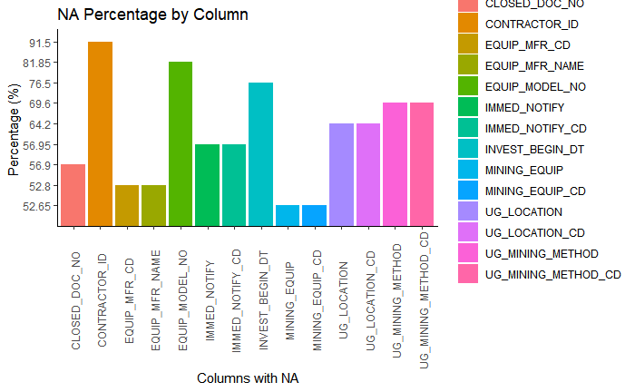

```r
options(repr.plot.width = 1200, repr.plot.height = 8)
df %>%
    ggplot() +
    geom_col(mapping = aes(x=Col, y = Per , fill=Col)) +
    labs(x = "Columns with NA", y="Percentage (%) ", title ="NA Percentage by Column")+
    theme(axis.text.x = element_text(angle = 90, vjust = 0.6))
```

Dropping Columns

We will now drop all the columns that have NA percentage greater than 50%.

```r
accidents <- accidents %>% select(-all_of(df$Col))
```

There are some unuseful variables in the dataset which will not give us insights about mines accident like MINE_ID, CONTROLLER_ID, OPERATOR_ID, NARRATIVE, DOCUMENT_NO, FIPS_STATE_CD,CAL_YR

```r
not_useful <- c("MINE_ID", "CONTROLLER_ID", "OPERATOR_ID", "NARRATIVE", "DOCUMENT_NO","FIPS_STATE_CD","CAL_YR")
accidents <- accidents %>% select(-all_of(not_useful))
```

Some columns have many unique values therefore it should be removed because they will not be use in the visualization like CONTROLLER_NAME, OPERATOR_NAME

```r
length(unique(accidents$CONTROLLER_NAME))
```

```
[1] 607
```

```r
length(unique(accidents$OPERATOR_NAME))
```

```
[1] 874
```

```r
not_useful <- c("CONTROLLER_NAME", "OPERATOR_NAME")
accidents <- accidents %>% select(-all_of(not_useful))
```

Dealing with NA values in Integer and Float Columns

We will modify the NA values of columns (DAYS_LOST, DAYS_RESTRICT, SCHEDULE_CHARGE, TOT_EXPER, MINE_EXPER, JOB_EXPER) with the median of the column because the data is Skewed.

Add values to “DAYS_LOST” Column

```r
summary(accidents$DAYS_LOST)
```

```
   Min. 1st Qu.  Median    Mean 3rd Qu.    Max.    NA's
   0.00    0.00    0.00   22.74   16.00  500.00     422
```

```r
accidents$DAYS_LOST[is.na(accidents$DAYS_LOST)] <- median(accidents$DAYS_LOST, na.rm = T)
 median(accidents$DAYS_LOST, na.rm = T)
```

```
[1] 0
```

Add values to “DAYS_RESTRICT” Column

```r
summary(accidents$DAYS_RESTRICT)
```

```
   Min. 1st Qu.  Median    Mean 3rd Qu.    Max.    NA's
  0.000   0.000   0.000   9.204   6.000 350.000     543
```

```r
accidents$DAYS_RESTRICT[is.na(accidents$DAYS_RESTRICT)] <- median(accidents$DAYS_RESTRICT, na.rm = T)
median(accidents$DAYS_RESTRICT, na.rm = T)
```

```
[1] 0
```

Add values to “SCHEDULE_CHARGE” Column

```r
summary(accidents$SCHEDULE_CHARGE)
```

```
   Min. 1st Qu.  Median    Mean 3rd Qu.    Max.    NA's
   0.00    0.00    0.00   74.18    0.00 6000.00     673
```

```r
accidents$SCHEDULE_CHARGE[is.na(accidents$SCHEDULE_CHARGE)] <- median(accidents$SCHEDULE_CHARGE, na.rm = T)
median(accidents$SCHEDULE_CHARGE, na.rm = T)
```

```
[1] 0
```

Add values to “TOT_EXPER” Column

```r
summary(accidents$TOT_EXPER)
```

```
   Min. 1st Qu.  Median    Mean 3rd Qu.    Max.    NA's
   0.01    2.00    7.00   11.02   18.29   46.00     360
```

```r
accidents$TOT_EXPER[is.na(accidents$TOT_EXPER)] <- median(accidents$TOT_EXPER, na.rm = T)
median(accidents$TOT_EXPER, na.rm = T)
```

```
[1] 7
```

Add values to “MINE_EXPER” Column

```r
summary(accidents$MINE_EXPER)
```

```
   Min. 1st Qu.  Median    Mean 3rd Qu.    Max.    NA's
  0.010   0.900   3.000   6.926   9.690  43.000     333
```

```r
accidents$MINE_EXPER[is.na(accidents$MINE_EXPER)] <- median(accidents$MINE_EXPER, na.rm = T)
median(accidents$MINE_EXPER, na.rm = T)
```

```
[1] 3
```

Add values to “JOB_EXPER” Column

```r
summary(accidents$JOB_EXPER)
```

```
   Min. 1st Qu.  Median    Mean 3rd Qu.    Max.    NA's
  0.010   1.000   3.460   6.953  10.000  41.730     328
```

```r
accidents$JOB_EXPER[is.na(accidents$JOB_EXPER)] <- median(accidents$JOB_EXPER, na.rm = T)
median(accidents$JOB_EXPER, na.rm = T)
```

```
[1] 3.46
```

Dealing with NA values in String Columns

We will fill all the NA values with the mode of the column which means the value which is repeating highest number of times.

Add values to “TRANS_TERM” Column

```r
uniqx <- unique(accidents$TRANS_TERM)
accidents$TRANS_TERM[is.na(accidents$TRANS_TERM)] <- uniqx[which.max(tabulate(match(accidents, uniqx)))]
```

Add values to “DEGREE_INJURY” Column

```r
uniqx <- unique(accidents$DEGREE_INJURY)
accidents$DEGREE_INJURY[is.na(accidents$DEGREE_INJURY)] <- uniqx[which.max(tabulate(match(accidents, uniqx)))]

uniqx <- unique(accidents$DEGREE_INJURY_CD)
accidents$DEGREE_INJURY_CD[is.na(accidents$DEGREE_INJURY_CD)] <- uniqx[which.max(tabulate(match(accidents, uniqx)))]
```

```r
uniqx <- unique(accidents$NATURE_INJURY)
accidents$NATURE_INJURY[is.na(accidents$NATURE_INJURY)] <- uniqx[which.max(tabulate(match(accidents, uniqx)))]

uniqx <- unique(accidents$NATURE_INJURY_CD)
accidents$NATURE_INJURY_CD[is.na(accidents$NATURE_INJURY_CD)] <- uniqx[which.max(tabulate(match(accidents, uniqx)))]
```

```r
uniqx <- unique(accidents$CLASSIFICATION_CD)
accidents$CLASSIFICATION_CD[is.na(accidents$CLASSIFICATION_CD)] <- uniqx[which.max(tabulate(match(accidents, uniqx)))]

uniqx <- unique(accidents$CLASSIFICATION)
accidents$CLASSIFICATION[is.na(accidents$CLASSIFICATION)] <- uniqx[which.max(tabulate(match(accidents, uniqx)))]
```

```r
uniqx <- unique(accidents$ACCIDENT_TYPE_CD)
accidents$ACCIDENT_TYPE_CD[is.na(accidents$ACCIDENT_TYPE_CD)] <- uniqx[which.max(tabulate(match(accidents, uniqx)))]

uniqx <- unique(accidents$ACCIDENT_TYPE)
accidents$ACCIDENT_TYPE[is.na(accidents$ACCIDENT_TYPE)] <- uniqx[which.max(tabulate(match(accidents, uniqx)))]
```

```r
uniqx <- unique(accidents$OCCUPATION_CD)
accidents$OCCUPATION_CD[is.na(accidents$OCCUPATION_CD)] <- uniqx[which.max(tabulate(match(accidents, uniqx)))]

uniqx <- unique(accidents$OCCUPATION)
accidents$OCCUPATION[is.na(accidents$OCCUPATION)] <- uniqx[which.max(tabulate(match(accidents, uniqx)))]
```

```r
uniqx <- unique(accidents$ACTIVITY)
accidents$ACTIVITY[is.na(accidents$ACTIVITY)] <- uniqx[which.max(tabulate(match(accidents, uniqx)))]

uniqx <- unique(accidents$ACTIVITY_CD)
accidents$ACTIVITY_CD[is.na(accidents$ACTIVITY_CD)] <- uniqx[which.max(tabulate(match(accidents, uniqx)))]
```

```r
uniqx <- unique(accidents$INJURY_SOURCE_CD)
accidents$INJURY_SOURCE_CD[is.na(accidents$INJURY_SOURCE_CD)] <- uniqx[which.max(tabulate(match(accidents, uniqx)))]

uniqx <- unique(accidents$INJURY_SOURCE)
accidents$INJURY_SOURCE[is.na(accidents$INJURY_SOURCE)] <- uniqx[which.max(tabulate(match(accidents, uniqx)))]
```

```r
uniqx <- unique(accidents$INJ_BODY_PART_CD)
accidents$INJ_BODY_PART_CD[is.na(accidents$INJ_BODY_PART_CD)] <- uniqx[which.max(tabulate(match(accidents, uniqx)))]

uniqx <- unique(accidents$INJ_BODY_PART)
accidents$INJ_BODY_PART[is.na(accidents$INJ_BODY_PART)] <- uniqx[which.max(tabulate(match(accidents, uniqx)))]
```

Transforming date column for visualization

We will seperate the Date, month and Year to analyze

```r
accidents %>% select(ACCIDENT_DT) %>% head(5)
```

|  | ACCIDENT_DT |
| --- | --- |
| 1 | 14/03/2012 |
| 2 | 8/01/2007 |
| 3 | 4/07/2009 |
| 4 | 26/05/2000 |
| 5 | 22/01/2005 |

```r
  accidents <- accidents %>%
  separate(ACCIDENT_DT, into = c("ACCIDENT_DATE", "ACCIDENT_MONTH","ACCIDENT_YEAR"), sep = "/")

  accidents %>%
  select(ACCIDENT_DATE, ACCIDENT_MONTH, ACCIDENT_YEAR) %>%
  head(5)
```

|  | ACCIDENT_DATE | ACCIDENT_MONTH | ACCIDENT_YEAR |
| --- | --- | --- | --- |
| 1 | 14 | 03 | 2012 |
| 2 | 8 | 01 | 2007 |
| 3 | 4 | 07 | 2009 |
| 4 | 26 | 05 | 2000 |
| 5 | 22 | 01 | 2005 |

Adding our clean and final data to new file after all data cleaning process and transformation.

```r
write_csv(accidents, "finalaccidents.csv")
```

EDA (Exploratory Data Analysis And Visualization)

Reading clean data

```r
accidents <- read_csv("./finalaccidents.csv", show_col_types = FALSE)
view(accidents)
summary(accidents)
```

```
   SUBUNIT_CD       SUBUNIT          ACCIDENT_DATE  ACCIDENT_MONTH     ACCIDENT_YEAR     CAL_QTR
 Min.   : 1.000   Length:2000        Min.   : 1.0   Length:2000        Min.   :2000   Min.   :1.000
 1st Qu.: 1.000   Class :character   1st Qu.: 8.0   Class :character   1st Qu.:2002   1st Qu.:1.000
 Median : 3.000   Mode  :character   Median :15.0   Mode  :character   Median :2006   Median :2.000
 Mean   : 9.996                      Mean   :15.2                      Mean   :2006   Mean   :2.458
 3rd Qu.:30.000                      3rd Qu.:22.0                      3rd Qu.:2009   3rd Qu.:3.000
 Max.   :99.000                      Max.   :31.0                      Max.   :2015   Max.   :4.000

   FISCAL_YR      FISCAL_QTR    ACCIDENT_TIME  DEGREE_INJURY_CD DEGREE_INJURY      SHIFT_BEGIN_TIME
 Min.   :2000   Min.   :1.000   Min.   :  10   Min.   : 0.00    Length:2000        Min.   :   1
 1st Qu.:2002   1st Qu.:2.000   1st Qu.: 845   1st Qu.: 3.00    Class :character   1st Qu.: 630
 Median :2006   Median :3.000   Median :1208   Median : 5.00    Mode  :character   Median : 700
 Mean   :2006   Mean   :2.574   Mean   :1801   Mean   : 4.14                       Mean   :1416
 3rd Qu.:2010   3rd Qu.:4.000   3rd Qu.:1646   3rd Qu.: 6.00                       3rd Qu.:1530
 Max.   :2015   Max.   :4.000   Max.   :9999   Max.   :10.00                       Max.   :9999
                                                                                   NA's   :9
 CLASSIFICATION_CD CLASSIFICATION     ACCIDENT_TYPE_CD ACCIDENT_TYPE       NO_INJURIES       TOT_EXPER
 Min.   : 1.00     Length:2000        Min.   : 1.00    Length:2000        Min.   : 0.000   Min.   : 0.010
 1st Qu.: 9.00     Class :character   1st Qu.: 8.00    Class :character   1st Qu.: 1.000   1st Qu.: 2.873
 Median :10.00     Mode  :character   Median :21.00    Mode  :character   Median : 1.000   Median : 7.000
 Mean   :12.73                        Mean   :19.84                       Mean   : 0.923   Mean   :10.297
 3rd Qu.:17.00                        3rd Qu.:30.00                       3rd Qu.: 1.000   3rd Qu.:15.000
 Max.   :32.00                        Max.   :44.00                       Max.   :16.000   Max.   :46.000

   MINE_EXPER       JOB_EXPER     OCCUPATION_CD    OCCUPATION         ACTIVITY_CD      ACTIVITY
 Min.   : 0.010   Min.   : 0.01   Min.   :  1.0   Length:2000        Min.   : 2.00   Length:2000
 1st Qu.: 1.000   1st Qu.: 1.17   1st Qu.:149.0   Class :character   1st Qu.:28.00   Class :character
 Median : 3.000   Median : 3.46   Median :316.0   Mode  :character   Median :30.00   Mode  :character
 Mean   : 6.272   Mean   : 6.38   Mean   :276.1                      Mean   :43.96
 3rd Qu.: 7.515   3rd Qu.: 8.47   3rd Qu.:374.0                      3rd Qu.:55.00
 Max.   :43.000   Max.   :41.73   Max.   :675.0                      Max.   :99.00

 INJURY_SOURCE_CD INJURY_SOURCE      NATURE_INJURY_CD NATURE_INJURY      INJ_BODY_PART_CD INJ_BODY_PART
 Min.   :  1.00   Length:2000        Min.   :100.0    Length:2000        Min.   :100.0    Length:2000
 1st Qu.: 57.00   Class :character   1st Qu.:180.0    Class :character   1st Qu.:330.0    Class :character
 Median : 86.00   Mode  :character   Median :220.0    Mode  :character   Median :420.0    Mode  :character
 Mean   : 76.63                      Mean   :244.1                       Mean   :428.4
 3rd Qu.: 90.00                      3rd Qu.:330.0                       3rd Qu.:520.0
 Max.   :127.00                      Max.   :400.0                       Max.   :900.0

 SCHEDULE_CHARGE   DAYS_RESTRICT       DAYS_LOST       TRANS_TERM        RETURN_TO_WORK_DT  COAL_METAL_IND
 Min.   :   0.00   Min.   :  0.000   Min.   :  0.00   Length:2000        Length:2000        Length:2000
 1st Qu.:   0.00   1st Qu.:  0.000   1st Qu.:  0.00   Class :character   Class :character   Class :character
 Median :   0.00   Median :  0.000   Median :  0.00   Mode  :character   Mode  :character   Mode  :character
 Mean   :  49.22   Mean   :  6.705   Mean   : 17.94
 3rd Qu.:   0.00   3rd Qu.:  1.000   3rd Qu.:  7.25
 Max.   :6000.00   Max.   :350.000   Max.   :500.00
```

Locations in Mine where most accidents occured

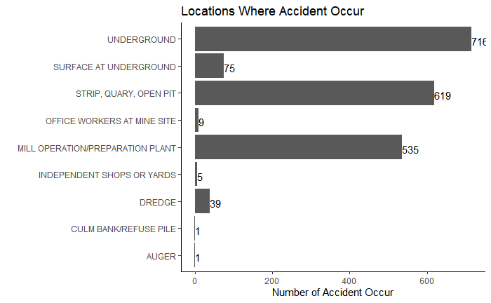

```r
ggplot(accidents, aes(x = SUBUNIT)) +
  geom_bar() +
  labs(x = "",
       y = "Number of Accident Occur",
       title = "Locations Where Accident Occur") + geom_text(stat='count', aes(label=..count..), vjust=0.7, hjust = 0)+
  coord_flip()
```

We can see that most of the Accidents occur in Mine were in Underground location.

Degree of Injury Percentage in Metal/Non Metal or Coal Mines

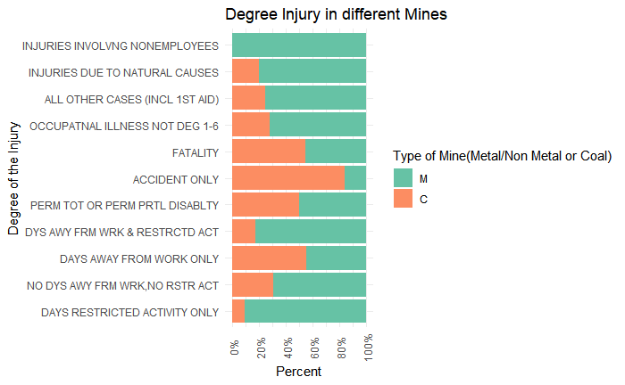

```r
ggplot(accidents,
       aes(x = factor(DEGREE_INJURY,
                      levels = unique(DEGREE_INJURY)),
           fill = factor(COAL_METAL_IND,
                         levels =unique(COAL_METAL_IND),
                         labels = unique(COAL_METAL_IND)))) +
  geom_bar(position = "fill") + coord_flip()+
  scale_y_continuous(breaks = seq(0, 1, .2),
                     label = percent) +
  scale_fill_brewer(palette = "Set2") +
  labs(y = "Percent",
       fill = "Type of Mine(Metal/Non Metal or Coal)",
       x = "Degree of the Injury",
       title = "Degree Injury in different Mines") +
  theme_minimal() +
  theme(axis.text.x = element_text(angle = 90, vjust = 0.6))
```

Count of Accidents in every month of the past 15 Years

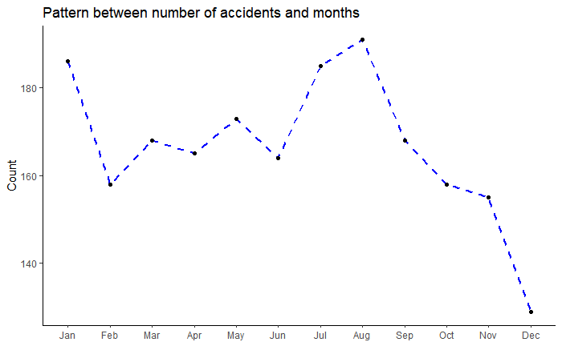

```r
g_top <- accidents %>%
  count(ACCIDENT_MONTH) %>%
  ggplot(aes(ACCIDENT_MONTH, n)) +
  geom_line(aes(group = 1), linetype = "dashed", size = 1, colour = "blue") +
  geom_point() +
  labs(y = "Count",
       x = NULL,
    title = "Pattern between number of accidents and months") +
  scale_x_discrete(labels = c("Jan", "Feb", "Mar", "Apr", "May",
                              "Jun", "Jul", "Aug", "Sep", "Oct",
                              "Nov", "Dec"))

g_top
```

Most of the Accidents occurred in the Month of August.

Persons terminated or transferred every year with respect to experience of working in mines

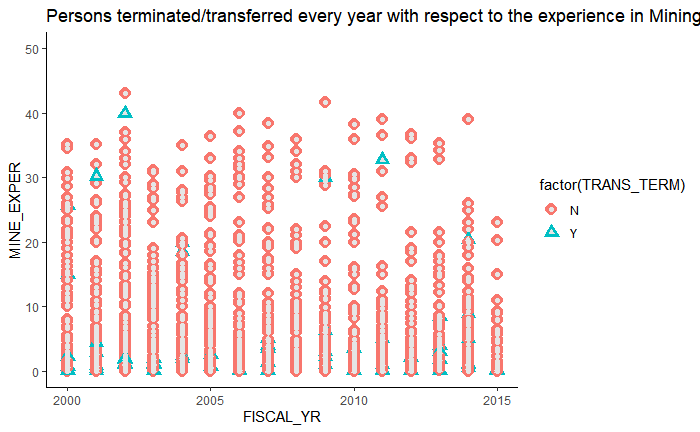

```r
p <- ggplot(accidents, aes(FISCAL_YR, MINE_EXPER, shape = factor(TRANS_TERM)))
p +
  geom_point(aes(colour = factor(TRANS_TERM)), size = 4) +
  geom_point(colour = "grey90", size = 1.5)+
  scale_y_continuous(limits=c(0.0, 50.0))+
  ggtitle("Persons terminated/transferred every year with respect to the experience in Mining")
```

We can see that maximum employees were termination or transferred were between 0 to 20 years of experince in the 15 years of Span.

Correlation between Injury and Accidents

```r
accidentsdf <- data.frame(accidents$CLASSIFICATION_CD, accidents$ACCIDENT_TYPE_CD, accidents$OCCUPATION_CD, accidents$ACTIVITY_CD, accidents$INJURY_SOURCE_CD, accidents$NATURE_INJURY_CD, accidents$INJ_BODY_PART_CD)

calc_mode <- function(x){

  # List the distinct / unique values
  distinct_values <- unique(x)

  # Count the occurrence of each distinct value
  distinct_tabulate <- tabulate(match(x, distinct_values))

  # Return the value with the highest occurrence
  distinct_values[which.max(distinct_tabulate)]
}

accidentsdf %>%
  mutate(across(everything(), ~replace_na(.x, calc_mode(.x)))) -> accidentsdf

for(i in 1:ncol(accidentsdf)){
  accidentsdf[,i] <- as.integer(accidentsdf[,i])
}
#sapply(accidentsdf, class)
```

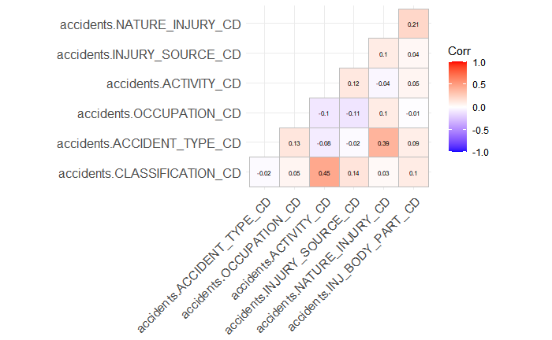

```r
cor(accidentsdf) %>% ggcorrplot(show.diag = F, type="lower", lab=TRUE, lab_size=2)
```

The maximum correlation is between Activity and Classification. Which means under which circumstance the injury occured and the task the injured person was performing that very moment.

Number of Days lost due to Injuries

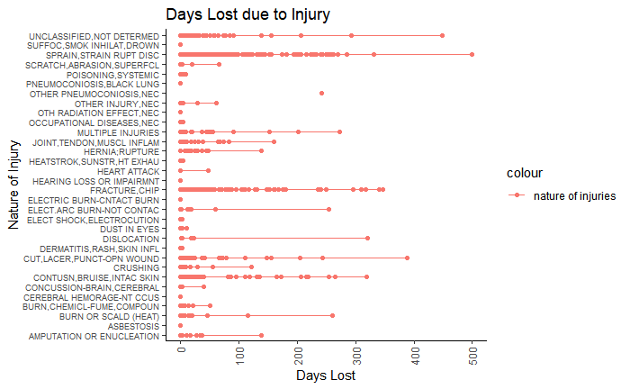

```r
accidents %>%
 ggplot(aes(x = NATURE_INJURY)) +  coord_flip()+
  geom_point(aes(y = DAYS_LOST, color = "nature of injuries")) +
  geom_line(aes(y = DAYS_LOST, color = "nature of injuries")) +
   theme(axis.text.x = element_text(angle = 90, vjust = 0.5, hjust=1)) +
  theme(axis.text.y = element_text(angle = 0, vjust = 0.5, hjust=1, size= 7)) +
  #scale_y_continuous(labels = scales::percent) +
  ggtitle("Days Lost due to Injury") +
  labs(x="Nature of Injury", y="Days Lost")
```

We can see that most of days lost from work is due to Sprain, strain or rupt disc injuries.

_________________________________________________*********************________________________________________________